# Generating dtopo files for CSZ fakequakes

### Modified to make plots to compare with new CoPes Hub ground motions

This notebooks demonstrates how the GeoClaw `dtopotools` module can be used to generate the dtopo file for a kinematic rupture specified on a set of triangular subfaults (available starting in Clawpack Version 5.5.0).

This uses one of the 1300 "fakequake" realizations from the paper

- *Kinematic rupture scenarios and synthetic displacement data: An example application to the Cascadia subduction zone* by Diego Melgar, R. J. LeVeque, Douglas S. Dreger, Richard M. Allen, J. Geophys. Res. -- Solid Earth 121 (2016), p. 6658. [doi:10.1002/2016JB013314](http://dx.doi.org/10.1002/2016JB013314).

This requires `cascadia30.mshout` containing the geometry of the triangulated fault surface, from https://github.com/dmelgarm/MudPy/blob/master/examples/fakequakes/3D/cascadia30.mshout

It also requires a rupture scenario in the form of a `.rupt` file from the collection of fakequakes archived at https://zenodo.org/record/59943#.WgHuahNSxE4.

This sample uses one rupture scenario, which can be changed by setting `rnum`.

# Version

Modified June 2024, Runs with Clawpack v5.10.0

```python
%matplotlib inline
```

```python
from clawpack.geoclaw import dtopotools, topotools
import matplotlib as mpl
import matplotlib.pyplot as plt
import numpy as np
from clawpack.visclaw.plottools import plotbox
import os
from clawpack.visclaw import animation_tools
from IPython.display import HTML
```

#### Set location of fakequakes downloaded from zenodo:

Also put `cascadia30.mshout` in this directory.

```python
fqdir = '/Users/rjl/D/fakequakes_cascadia'
```

## Load etopo1 topo and extract coastline for plotting

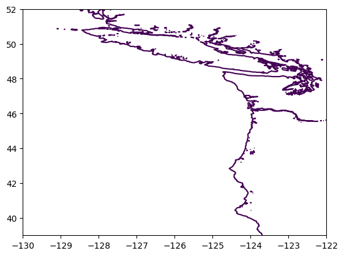

```python
extent = [-130,-122,39,52]
topo = topotools.read_netcdf('etopo1', extent=extent)

# generate coast_xy from etopo1 data:
coast_xy = topo.make_shoreline_xy()
```

### Set up CSZ geometry

```python
fault_geometry_file = '%s/cascadia30.mshout' % fqdir
print('Reading fault geometry from %s' % fault_geometry_file)
print('\nHeader:\n')
print(open(fault_geometry_file).readline())
```

```
Reading fault geometry from /Users/rjl/D/fakequakes_cascadia/cascadia30.mshout

Header:

#   fault No. , centroid(lon,lat,z[km]) , node1(lon,lat,z[km]) , node2(lon,lat,z[km]) , node3(lon,lat,z[km]) , mean vertex length(km) , area(km^2) , strike(deg) , dip(deg)
```

```python
# read in .mshout (CSZ geoemetry)

cascadia = np.loadtxt(fault_geometry_file,skiprows=1)
cascadia[:,[3,6,9,12]] = 1e3*abs(cascadia[:,[3,6,9,12]])

print('Loaded geometry for %i triangular subfaults' % cascadia.shape[0])
```

```
Loaded geometry for 963 triangular subfaults
```

For example, the first triangular fault in the given geometry of CSZ has the nodes

```python
print(cascadia[0,4:7])
print(cascadia[0,7:10])
print(cascadia[0,10:13])
```

```
[-125.36073    46.302805 8795.382   ]
[ -125.311684    46.526803 10094.313   ]
[ -125.038743    46.426986 13526.373   ]
```

### Plot the subfaults:

Set up a fault model with these subfaults, without yet specifying a particular earthquake scenario.

```python
fault0 = dtopotools.Fault()
fault0.subfaults = []

nsubfaults = cascadia.shape[0]

for j in range(nsubfaults):
    subfault0 = dtopotools.SubFault()
    node1 = cascadia[j,4:7].tolist()
    node2 = cascadia[j,7:10].tolist()
    node3 = cascadia[j,10:13].tolist()
    node_list = [node1,node2,node3]
    subfault0.set_corners(node_list,projection_zone='10')  # '10T' changed to '10'
    fault0.subfaults.append(subfault0)
```

Now we can plot the triangular subplots:

```
Created  CSZ_subfaults.png
```

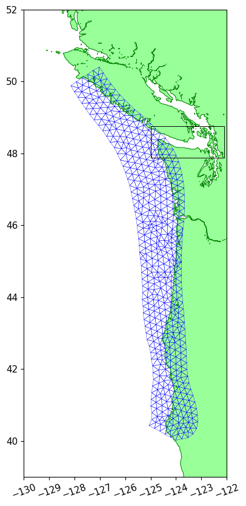

```python
fig = plt.figure(figsize=(15,10))
ax = plt.axes()
plt.contourf(topo.X, topo.Y, topo.Z, [0,10000], colors=[[.6,1,.6]])
for s in fault0.subfaults:
    c = s.corners
    c.append(c[0])
    c = np.array(c)
    ax.plot(c[:,0],c[:,1], 'b',linewidth=0.3)
plt.plot(coast_xy[:,0], coast_xy[:,1], 'g', linewidth=0.7)
plotbox([-125,-122.1,47.88,48.75], {'color':'k','linewidth':0.7})
ax.set_xlim(-130,-122)
ax.set_ylim(39,52)
ax.set_aspect(1./np.cos(45*np.pi/180.))
plt.xticks(rotation=20,fontsize=11)
plt.yticks(fontsize=11)
#ax.set_xlabel('Longitude')
#ax.set_ylabel('Latitude');
#ax.set_title('Triangular subfaults');
if 1:
    fname = 'CSZ_subfaults.png'
    plt.savefig(fname, bbox_inches='tight')
    print('Created ',fname)
```

### Rupture scenario

We now read in rupture scenario, using data from [https://zenodo.org/record/59943#.WgHuahNSxE4].

```python
datadir = '%s/data' % fqdir
```

```python
rnum = 1273
rupt_name = 'cascadia.%s' % str(rnum).zfill(6)
rupt_fname = '%s/%s/_%s.rupt' % (datadir, rupt_name, rupt_name)
print("Reading earthquake data from %s" % rupt_fname)
rupture_parameters = np.loadtxt(rupt_fname,skiprows=1)
```

```
Reading earthquake data from /Users/rjl/D/fakequakes_cascadia/data/cascadia.001273/_cascadia.001273.rupt
```

This data is used to set the slip and rake on each of the subfaults loaded above. Since this is a dynamic rupture, we also set the `rupture_time` and `rise_time` of each subfault.

```python
fault0 = dtopotools.Fault()
fault0.subfaults = []
fault0.rupture_type = 'kinematic'
rake = 90. # assume same rake for all subfaults

J = int(np.floor(cascadia.shape[0]))

for j in range(J):
    subfault0 = dtopotools.SubFault()
    node1 = cascadia[j,4:7].tolist()
    node2 = cascadia[j,7:10].tolist()
    node3 = cascadia[j,10:13].tolist()
    node_list = [node1,node2,node3]

    ss_slip = rupture_parameters[j,8]
    ds_slip = rupture_parameters[j,9]

    rake = np.rad2deg(np.arctan2(ds_slip, ss_slip))

    subfault0.set_corners(node_list,projection_zone='10')  # '10T' changed to '10'
    subfault0.rupture_time = rupture_parameters[j,12]
    subfault0.rise_time = rupture_parameters[j,7]
    subfault0.rake = rake

    slip = np.sqrt(ds_slip ** 2 + ss_slip ** 2)
    subfault0.slip = slip
    fault0.subfaults.append(subfault0)
```

### Compute seafloor deformations with GeoClaw

We now run the `create_dtopography` routine to generate dynamic seafloor deformations at a given set of times. This applies the Okada model to each of the subfaults and evaluates the surface displacement on the grid given by `x,y`, at each time. These are summed up over all subfaults to compute the total deformation.

```python
x,y = fault0.create_dtopo_xy(dx = 4/60.)
print('Will create dtopo on arrays of shape %i by %i' % (len(x),len(y)))
tfinal = max([subfault1.rupture_time + subfault1.rise_time for subfault1 in fault0.subfaults])
times0 = np.linspace(0.,tfinal,100)
dtopo0 = fault0.create_dtopography(x,y,times=times0,verbose=False);
```

```
Will create dtopo on arrays of shape 106 by 181
```

```python
x.shape,y.shape, dtopo0.dZ.shape
```

```
((106,), (181,), (100, 181, 106))
```

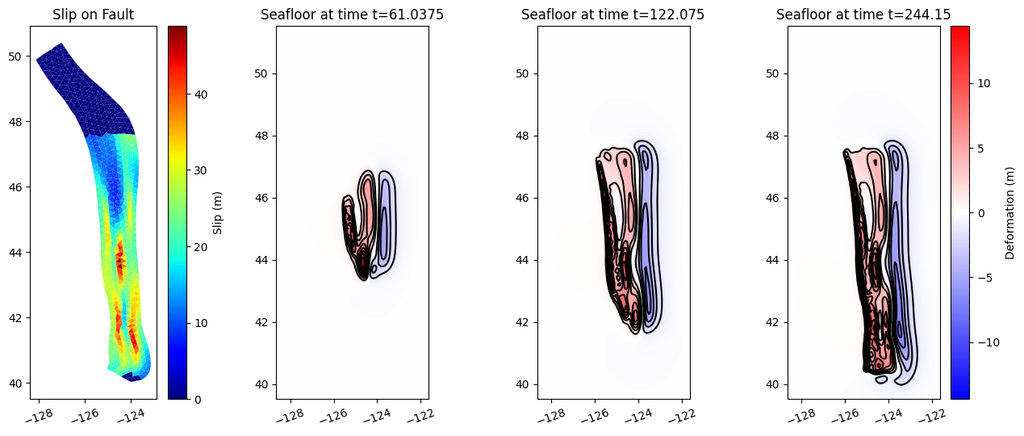

```python
fig,(ax0,ax1,ax2, ax3) = plt.subplots(ncols=4,nrows=1,figsize=(16,6))
fault0.plot_subfaults(axes=ax0,slip_color=True,plot_box=False);
ax0.set_title('Slip on Fault');

X = dtopo0.X; Y = dtopo0.Y; dZ_at_t = dtopo0.dZ_at_t
dz_max = dtopo0.dZ.max()

t0 = 0.25*tfinal    # time to plot deformation
dtopotools.plot_dZ_colors(X,Y,dZ_at_t(t0),axes=ax1,
                          cmax_dZ = dz_max, add_colorbar=False);
ax1.set_title('Seafloor at time t=' + str(t0));

t0 = 0.5*tfinal    # time to plot deformation
dtopotools.plot_dZ_colors(X,Y,dZ_at_t(t0),axes=ax2,
                          cmax_dZ = dz_max, add_colorbar=False);

ax2.set_title('Seafloor at time t=' + str(t0));

t0 = tfinal    # time to plot deformation
dtopotools.plot_dZ_colors(X,Y,dZ_at_t(t0),axes=ax3,
                          cmax_dZ = dz_max, add_colorbar=True);
ax3.set_title('Seafloor at time t=' + str(t0));

#fig.savefig('CSZ_triangular.png');
```

### Plot the rupture time and rise time of each subfault

This shows where the rupture originates and how it propagates outward. Each vertical bar shows the rupture time and duration of one subfault.

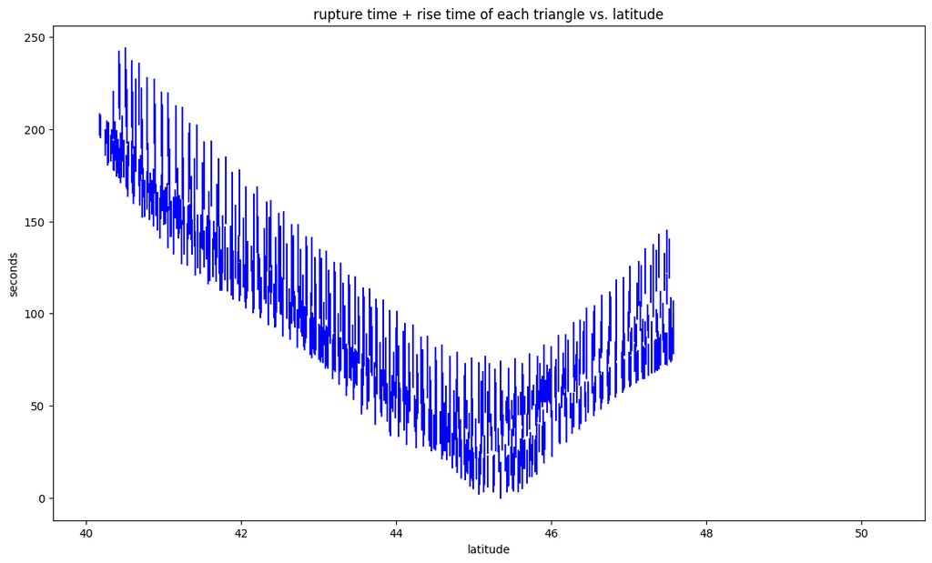

```python
plt.figure(figsize=(14,8))
plt.axes()
latitudes = [s.latitude for s in fault0.subfaults]
rise_times = [s.rise_time for s in fault0.subfaults]
rupture_times = [s.rupture_time for s in fault0.subfaults]
for j,lat in enumerate(latitudes):
    plt.plot([lat,lat],[rupture_times[j],rupture_times[j]+rise_times[j]],'b')
plt.xlabel('latitude')
plt.ylabel('seconds')
plt.title('rupture time + rise time of each triangle vs. latitude')
```

## Plots similar to those used in ML paper

```python
cmap = mpl.cm.jet
cmap.set_under(color='w', alpha=0)  # transparent for zero slip
```

```python
cmap_slip = mpl.cm.jet

def plot_triangular_slip(subfault,ax,cmin_slip,cmax_slip):
    x_corners = [subfault.corners[2][0],
                 subfault.corners[0][0],
                 subfault.corners[1][0],
                 subfault.corners[2][0]]

    y_corners = [subfault.corners[2][1],
                 subfault.corners[0][1],
                 subfault.corners[1][1],
                 subfault.corners[2][1]]

    slip = subfault.slip
    s = min(1, max(0, (slip-cmin_slip)/(cmax_slip-cmin_slip)))
    c = np.array(cmap_slip(s*.99))  # since 1 does not map properly with jet
    if slip <= cmin_slip:
        c[-1] = 0  # make transparent

    ax.fill(x_corners,y_corners,color=c,edgecolor='none')
```

```python
cmin_slip = 0.01  # smaller values will be transparent
cmax_slip = np.array([s.slip for s in fault0.subfaults]).max()
```

```
Created  cascadia_1273.png
```

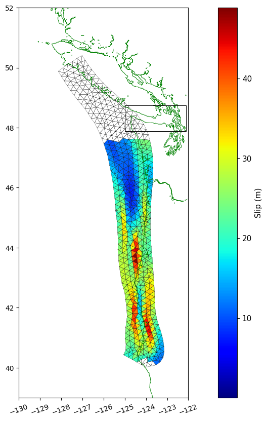

```python
fig = plt.figure(figsize=(15,10))
ax = plt.axes()
#plt.contourf(topo.X, topo.Y, topo.Z, [0,10000], colors=[[.6,1,.6]])
for s in fault0.subfaults:
    c = s.corners
    c.append(c[0])
    c = np.array(c)
    ax.plot(c[:,0],c[:,1], 'k', linewidth=0.2)
    plot_triangular_slip(s,ax,cmin_slip,cmax_slip)

plt.plot(coast_xy[:,0], coast_xy[:,1], 'g', linewidth=0.7)
plotbox([-125,-122.1,47.88,48.75], {'color':'k','linewidth':0.7})

if 0:
    fault0.plot_subfaults(axes=ax,slip_color=True,plot_box=False,
                      colorbar_ticksize=12, colorbar_labelsize=12);

ax.set_xlim(-130,-122)
ax.set_ylim(39,52)
ax.set_aspect(1./np.cos(45*np.pi/180.))
plt.xticks(rotation=20, fontsize=10)
plt.yticks(fontsize=10)
#ax.set_xlabel('Longitude')
#ax.set_ylabel('Latitude');
#ax.set_title('Triangular subfaults');

if 1:
    # add colorbar
    cax,kw = mpl.colorbar.make_axes(ax, shrink=1)
    norm = mpl.colors.Normalize(vmin=cmin_slip,vmax=cmax_slip)
    cb1 = mpl.colorbar.ColorbarBase(cax, cmap=cmap_slip, norm=norm)
    cb1.set_label("Slip (m)",fontsize=11)
    cb1.ax.tick_params(labelsize=11)

if 1:
    fname = 'cascadia_%s.png' % rnum
    plt.savefig(fname, bbox_inches='tight')
    print('Created ',fname)
```

### plot dtopo

```
Created  cascadia_1273_dtopo.png
```

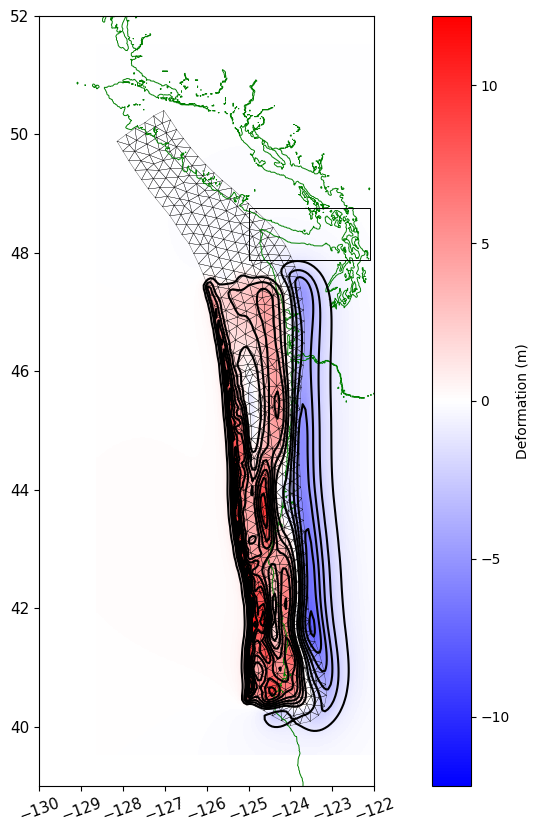

```python
fig = plt.figure(figsize=(15,10))
ax = plt.axes()
#plt.contourf(topo.X, topo.Y, topo.Z, [0,10000], colors=[[.6,1,.6]])
for s in fault0.subfaults:
    c = s.corners
    c.append(c[0])
    c = np.array(c)
    ax.plot(c[:,0],c[:,1], 'k', linewidth=0.2)
    #plot_triangular_slip(s,ax,cmin_slip,cmax_slip)

plt.plot(coast_xy[:,0], coast_xy[:,1], 'g', linewidth=0.7)
plotbox([-125,-122.1,47.88,48.75], {'color':'k','linewidth':0.7})

dtopo0.plot_dZ_colors(t=3600., axes=ax)

ax.set_xlim(-130,-122)
ax.set_ylim(39,52)
ax.set_aspect(1./np.cos(45*np.pi/180.))
plt.xticks(fontsize=11)
plt.yticks(fontsize=11)
#ax.set_xlabel('Longitude')
#ax.set_ylabel('Latitude');
ax.set_title('');

if 1:
    fname = 'cascadia_%s_dtopo.png' % rnum
    plt.savefig(fname, bbox_inches='tight')
    print('Created ',fname)
```

### Create dtopo file for running GeoClaw

```python
#ruptno = rupt_fname.split('.')[1]
fname = '%s.dtt3' % rupt_name
dtopo0.write(fname, dtopo_type=3)
print('Created %s, with dynamic rupture of a Mw %.2f event' % (fname, fault0.Mw()))
```

```
Created cascadia.001273.dtt3, with dynamic rupture of a Mw 9.31 event
```

## Compare to T-shirts and/or new ground motions

Read in T-shirt dtopos (original with no extension north)

```python
dtopoL = {}
for Tn in [1,2,3]:
    fname_dtopo = '/Users/rjl/git/CopesHubTsunamis/dtopo/CSZ_Tshirts/CSZ_L%i_noext.tt3' % Tn
    dtopoL[Tn] = dtopotools.DTopography(fname_dtopo, 3)
```

```python
if 0:
    linecolors = ['k','m','c']
    for y0 in np.arange(48,41,-1):
        j = np.where(dtopo0.y<y0)[0].max()
        plt.figure(figsize=(7,4))
        plt.plot(dtopo0.x,dtopo0.dZ[-1,j,:],'b',label=rupt_name)
        for Tn in [1,2,3]:
            j = np.where(dtopoL[Tn].y<y0)[0].max()
            plt.plot(dtopoL[Tn].x,dtopoL[Tn].dZ[-1,j,:],color=linecolors[Tn-1],
                 linestyle='--', label='L%i' % Tn)
        plt.xlim(-127,-122)
        plt.ylim(-5,15)
        plt.grid(True)
        plt.legend()
        plt.title('Transect of final dz at y = %.1f' % y0);
```

### New ground motions

```python
#dtopodir = '/Users/rjl/git/CopesHubTsunamis/dtopo/CSZ_groundmotions/dtopofiles'
dtopodir = '../CSZ_groundmotions/dtopofiles'
dtopo_groundmotion = {}
events = []

rupture = 'buried-locking-str10'
depth = 'deep'
event = '%s-%s' % (rupture,depth)
fname_dtopo = '%s/%s_instant.dtt3' % (dtopodir,event)
print('Reading ',fname_dtopo)
dtopo_groundmotion[event] = dtopotools.DTopography(fname_dtopo, 3)
events.append(event)
```

```
Reading  ../CSZ_groundmotions/dtopofiles/buried-locking-str10-deep_instant.dtt3
```

```
Created  cascadia001273_vs_buried-locking-str10-deep.png
```

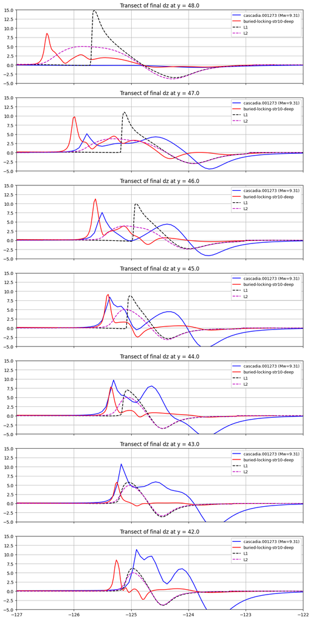

```python
linecolors = ['r','k','m']
y0s = list(np.arange(48,41,-1))
fig,axs = plt.subplots(len(y0s),1,figsize=(10,20),sharex=True)
for k,y0 in enumerate(y0s):
    ax = axs[k]
    j = np.where(dtopo0.y<y0)[0].max()
    ax.plot(dtopo0.x,dtopo0.dZ[-1,j,:],'b',
            label='%s (Mw=%.2f)' % (rupt_name, fault0.Mw()))
    for event in events:
        j = np.where(dtopo_groundmotion[event].y<y0)[0].max()
        ax.plot(dtopo_groundmotion[event].x, dtopo_groundmotion[event].dZ[-1,j,:],
                 color=linecolors[0], linestyle='-', label=event)
    for Tn in [1,2]:
        j = np.where(dtopoL[Tn].y<y0)[0].max()
        ax.plot(dtopoL[Tn].x, dtopoL[Tn].dZ[-1,j,:],color=linecolors[Tn],
             linestyle='--', label='L%i' % Tn)

    ax.set_xlim(-127,-122)
    ax.set_ylim(-5,15)
    ax.grid(True)
    ax.legend(loc='upper right', fontsize=9, framealpha=1)
    ax.set_title('Transect of final dz at y = %.1f' % y0);
plt.tight_layout()
fname = '%s_vs_%s.png' % (rupt_name.replace('.',''), event)
plt.savefig(fname, bbox_inches='tight')
print('Created ',fname)
```

```python
if 0:
    # loop over several events...
    events = []
    depths = ['deep','middle','shallow']
    rupture = 'buried-locking-str10'
    for depth in depths:
        events.append('%s-%s_instant' % (rupture,depth))

        fname_dtopo = 'dtopofiles/' + event + '.dtt3'
        print('Reading ',fname_dtopo)
        dtopo = dtopotools.DTopography(fname_dtopo, 3)
```